# Homework 02 - 3.2, 3.4, 3.18, 3.22, 3.38, 3.42

Max Wagner

September 26, 2015

3.2

```r
1 - pnorm(-1.13)
```

```
## [1] 0.8707619
```

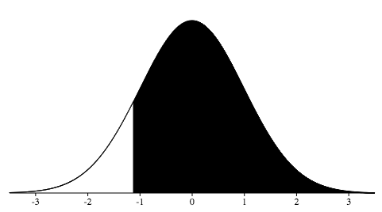

```r
pnorm(.18)
```

```
## [1] 0.5714237
```

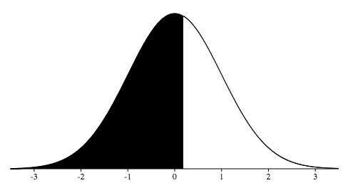

```r
1 - pnorm(8)
```

```
## [1] 6.661338e-16
```

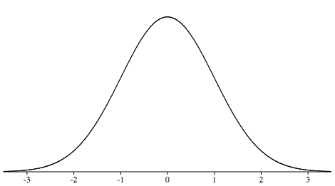

```r
(1 - pnorm(.5)) + (pnorm(-.5))
```

```
## [1] 0.6170751
```

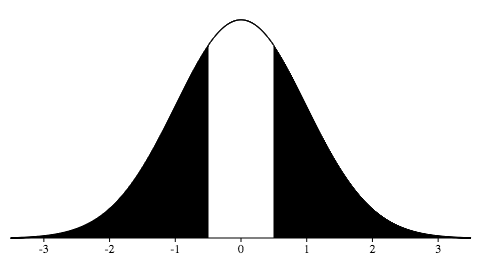

3.4

1. N(µ = 4313, σ = 583), N(µ = 5261, σ = 807)
2. The z-scores tell me that Leo is 1.09 sd’s from the mean, and Mary is .31 sd’s from the mean.

```r
leo_z <- (4948 - 4313) / 583; leo_z
```

```
## [1] 1.089194
```

```r
mary_z <- (5513 - 5261) / 807; mary_z
```

```
## [1] 0.3122677
```

3. Mary ranked better than Leo. Both are positive, which means they are above the mean time, but Mary’s z-score is lower than Leo’s, meaning she is closer to the mean.
4. The percentage is the (1 - pnorm).

```r
leo_per <- pnorm(leo_z); 1 - leo_per
```

```
## [1] 0.1380342
```

5. The percentage is the (1 - pnorm).

```r
mary_per <- pnorm(mary_z); 1 - mary_per
```

```
## [1] 0.3774186
```

6. Z-scores would still be able to be calculated, but d and e would not be possible without a normal plot.

3.18

1. 68% of score fall within 1σ, 96% within 2σ, and 100% within 3σ.

```r
range_68 <- c((61.52 - 4.58), (61.52 + 4.58)); range_68
```

```
## [1] 56.94 66.10
```

```r
per_68 <- (21 - 4) / 25; per_68
```

```
## [1] 0.68
```

```r
range_95 <- c((61.52 - 4.58 * 2), (61.52 + 4.58 * 2)); range_95
```

```
## [1] 52.36 70.68
```

```r
per_95 <- 24 / 25; per_95
```

```
## [1] 0.96
```

```r
range_997 <- c((61.52 - 4.58 * 3), (61.52 + 4.58 * 3)); range_997
```

```
## [1] 47.78 75.26
```

2. The distribution is unimodal and symmetrical, with the curve looking normal. The normal probability plot follows a relatively straight line, with 2 outliers, neither of which are extreme.

3.22

```r
x <- ((1 - .02) ^ 9) * .02; x
```

```
## [1] 0.01667496
```

```r
x <- (1 - .02) ^ 100; x
```

```
## [1] 0.1326196
```

```r
expected <- (1 / .02); expected
```

```
## [1] 50
```

```r
sd <- sqrt((1 - .02) / (.02 ^ 2)); sd
```

```
## [1] 49.49747
```

```r
expected <- (1 / .05); expected
```

```
## [1] 20
```

```r
sd <- sqrt((1 - .05) / (.05 ^ 2)); sd
```

```
## [1] 19.49359
```

5. The mean and sd of a success are lower when the probability is higher.

3.38

```r
p1 <- factorial(3) / (factorial(2) * factorial(3 - 2))
p2 <- (.51 ^ 2) * (.49 ^ 1)
answer <- p1 * p2; answer
```

```
## [1] 0.382347
```

2. In any of these cases, the probability will remain the same, as they all include 2 successes and 1 failure. If the parents stopped having children after the 2nd boy, it would be different.

```r
matrix(c("G", "B", "B", "B", "G", "B", "B", "B", "G"), byrow = T, nrow = 3)
```

```
##      [,1] [,2] [,3]
## [1,] "G"  "B"  "B"
## [2,] "B"  "G"  "B"
## [3,] "B"  "B"  "G"
```

Using the addition rule for disjoint outcomes works out the same answer.

```r
.49 * .51 * .51 * 3
```

```
## [1] 0.382347
```

3. Part a. only requires one formula, and one probability, whereas part b. require entering multiple probabilites multiple times.

3.42

```r
p1 <- (factorial(10 - 1)) / (factorial(3 - 1) * factorial(10 - 3))
p2 <- (.15 ^ 3) * (.85 ^ 7)
answer <- p1 * p2; answer
```

```
## [1] 0.03895012
```

```r
p1 <- factorial(10) / (factorial(3) * factorial(10 - 3))
p2 <- (.15 ^ 3) * (.85 ^ 7)
answer <- p1 * p2; answer
```

```
## [1] 0.1298337
```

3. The difference between a. and b., is that a. is calculated with a good serve on the 10th trial, whereas b. is calculated without a preset 10th trial.